# Risk Factor Analysis

## Outcome Variable

**Outcome Variable:** pers_wasted624

## Predictor Variables

**Intervention Variable:** ever_stunted06

**Adjustment Set:**

unadjusted

## Stratifying Variables

The analysis was stratified on these variable(s):

- studyid
- country

## Data Summary

| studyid | country | ever_stunted06 | pers_wasted624 | n_cell | n | outcome_variable |
| --- | --- | --- | --- | --- | --- | --- |
| CMC-V-BCS-2002 | INDIA | 0 | 0 | 167 | 370 | pers_wasted624 |
| CMC-V-BCS-2002 | INDIA | 0 | 1 | 11 | 370 | pers_wasted624 |
| CMC-V-BCS-2002 | INDIA | 1 | 0 | 175 | 370 | pers_wasted624 |
| CMC-V-BCS-2002 | INDIA | 1 | 1 | 17 | 370 | pers_wasted624 |
| CMIN | BANGLADESH | 0 | 0 | 107 | 252 | pers_wasted624 |
| CMIN | BANGLADESH | 0 | 1 | 3 | 252 | pers_wasted624 |
| CMIN | BANGLADESH | 1 | 0 | 120 | 252 | pers_wasted624 |
| CMIN | BANGLADESH | 1 | 1 | 22 | 252 | pers_wasted624 |
| COHORTS | GUATEMALA | 0 | 0 | 555 | 1023 | pers_wasted624 |
| COHORTS | GUATEMALA | 0 | 1 | 12 | 1023 | pers_wasted624 |
| COHORTS | GUATEMALA | 1 | 0 | 427 | 1023 | pers_wasted624 |
| COHORTS | GUATEMALA | 1 | 1 | 29 | 1023 | pers_wasted624 |
| COHORTS | INDIA | 0 | 0 | 4740 | 6893 | pers_wasted624 |
| COHORTS | INDIA | 0 | 1 | 420 | 6893 | pers_wasted624 |
| COHORTS | INDIA | 1 | 0 | 1382 | 6893 | pers_wasted624 |
| COHORTS | INDIA | 1 | 1 | 351 | 6893 | pers_wasted624 |
| COHORTS | PHILIPPINES | 0 | 0 | 1889 | 2809 | pers_wasted624 |
| COHORTS | PHILIPPINES | 0 | 1 | 108 | 2809 | pers_wasted624 |
| COHORTS | PHILIPPINES | 1 | 0 | 694 | 2809 | pers_wasted624 |
| COHORTS | PHILIPPINES | 1 | 1 | 118 | 2809 | pers_wasted624 |
| CONTENT | PERU | 0 | 0 | 186 | 215 | pers_wasted624 |
| CONTENT | PERU | 0 | 1 | 0 | 215 | pers_wasted624 |
| CONTENT | PERU | 1 | 0 | 29 | 215 | pers_wasted624 |
| CONTENT | PERU | 1 | 1 | 0 | 215 | pers_wasted624 |
| EE | PAKISTAN | 0 | 0 | 83 | 373 | pers_wasted624 |
| EE | PAKISTAN | 0 | 1 | 8 | 373 | pers_wasted624 |
| EE | PAKISTAN | 1 | 0 | 241 | 373 | pers_wasted624 |
| EE | PAKISTAN | 1 | 1 | 41 | 373 | pers_wasted624 |
| GMS-Nepal | NEPAL | 0 | 0 | 339 | 590 | pers_wasted624 |
| GMS-Nepal | NEPAL | 0 | 1 | 58 | 590 | pers_wasted624 |

[output cut: 90 more lines]

The following strata were considered:

- studyid: CMC-V-BCS-2002, country: INDIA
- studyid: CMIN, country: BANGLADESH
- studyid: COHORTS, country: GUATEMALA
- studyid: COHORTS, country: INDIA
- studyid: COHORTS, country: PHILIPPINES
- studyid: CONTENT, country: PERU
- studyid: EE, country: PAKISTAN
- studyid: GMS-Nepal, country: NEPAL
- studyid: Guatemala BSC, country: GUATEMALA
- studyid: IRC, country: INDIA
- studyid: JiVitA-3, country: BANGLADESH
- studyid: JiVitA-4, country: BANGLADESH
- studyid: Keneba, country: GAMBIA
- studyid: LCNI-5, country: MALAWI
- studyid: MAL-ED, country: BANGLADESH
- studyid: MAL-ED, country: BRAZIL
- studyid: MAL-ED, country: INDIA
- studyid: MAL-ED, country: NEPAL
- studyid: MAL-ED, country: PERU
- studyid: MAL-ED, country: SOUTH AFRICA
- studyid: MAL-ED, country: TANZANIA, UNITED REPUBLIC OF
- studyid: NIH-Birth, country: BANGLADESH
- studyid: NIH-Crypto, country: BANGLADESH
- studyid: PROBIT, country: BELARUS
- studyid: PROVIDE, country: BANGLADESH
- studyid: ResPak, country: PAKISTAN
- studyid: SAS-CompFeed, country: INDIA
- studyid: SAS-FoodSuppl, country: INDIA
- studyid: TanzaniaChild2, country: TANZANIA, UNITED REPUBLIC OF
- studyid: ZVITAMBO, country: ZIMBABWE

### Dropped Strata

Some strata were dropped due to rare outcomes:

- studyid: CMIN, country: BANGLADESH
- studyid: CONTENT, country: PERU
- studyid: Guatemala BSC, country: GUATEMALA
- studyid: LCNI-5, country: MALAWI
- studyid: MAL-ED, country: BRAZIL
- studyid: MAL-ED, country: NEPAL
- studyid: MAL-ED, country: PERU
- studyid: MAL-ED, country: SOUTH AFRICA
- studyid: MAL-ED, country: TANZANIA, UNITED REPUBLIC OF
- studyid: PROBIT, country: BELARUS

## Methods Detail

We’re interested in the causal parameters $E[Y_a]$ for all values of $a \in \mathcal{A}$. These parameters represent the mean outcome if, possibly contrary to fact, we intervened to set all units to have $A=a$. Under the randomization and positivity assumptions, these are identified by the statistical parameters $\psi_a=E_W[E_{Y|A,W}(Y|A=a,W)]$. In addition, we’re interested in the mean of $Y$, $E[Y]$ under no intervention (the observed mean). We will estimate these parameters by using SuperLearner to fit the relevant likelihood factors – $E_{Y|A,W}(Y|A=a,W)$ and $p(A=a|W)$, and then updating our likelihood fit using a joint TMLE.

For unadjusted analyses ($W=\{\}$), initial likelihoods were estimated using Lrnr_glm to estimate the simple $E(Y|A)$ and Lrnr_mean to estimate $p(A)$. For adjusted analyses, a small library containing Lrnr_glmnet, Lrnr_xgboost, and Lrnr_mean was used.

Having estimated these parameters, we will then use the delta method to estimate relative risks and attributable risks relative to a prespecified baseline level of $A$.

# Results Detail

## Results Plots

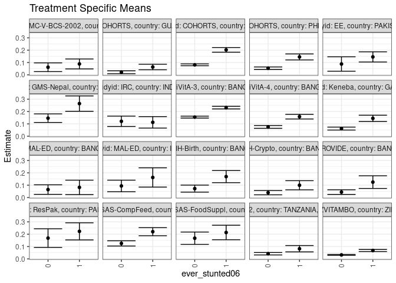

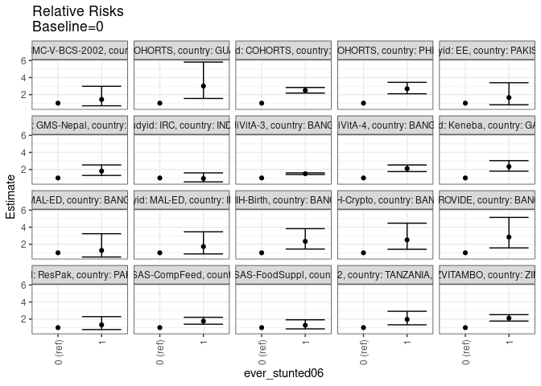

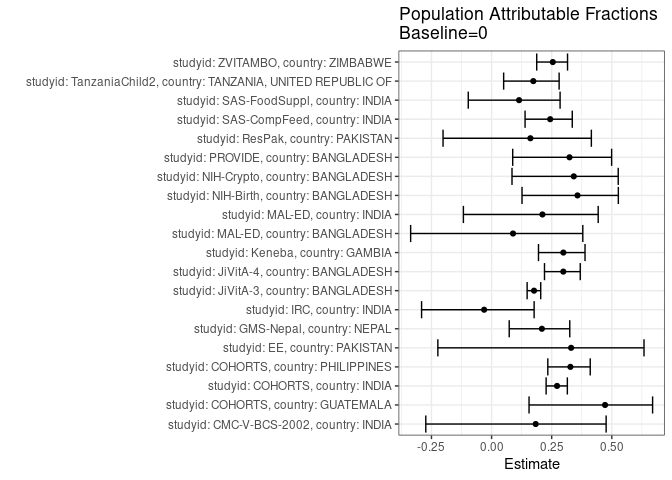

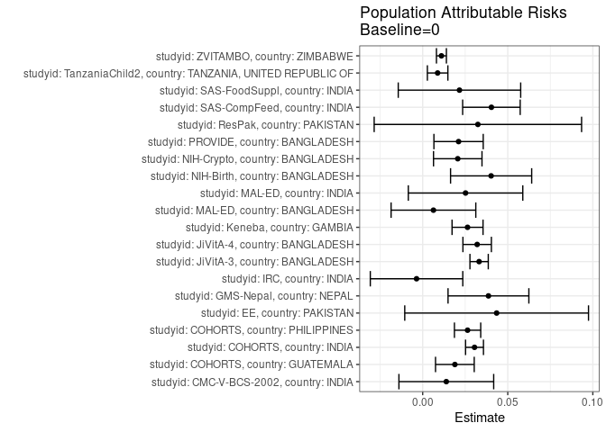

## Results Table

### Parameter: TSM

| studyid | country | intervention_level | baseline_level | estimate | ci_lower | ci_upper |
| --- | --- | --- | --- | --- | --- | --- |
| CMC-V-BCS-2002 | INDIA | 0 | NA | 0.0617978 | 0.0263768 | 0.0972187 |
| CMC-V-BCS-2002 | INDIA | 1 | NA | 0.0885417 | 0.0483045 | 0.1287788 |
| COHORTS | GUATEMALA | 0 | NA | 0.0211640 | 0.0093112 | 0.0330169 |
| COHORTS | GUATEMALA | 1 | NA | 0.0635965 | 0.0411873 | 0.0860057 |
| COHORTS | INDIA | 0 | NA | 0.0813953 | 0.0739340 | 0.0888567 |
| COHORTS | INDIA | 1 | NA | 0.2025389 | 0.1836160 | 0.2214619 |
| COHORTS | PHILIPPINES | 0 | NA | 0.0540811 | 0.0441594 | 0.0640028 |
| COHORTS | PHILIPPINES | 1 | NA | 0.1453202 | 0.1210758 | 0.1695646 |
| EE | PAKISTAN | 0 | NA | 0.0879121 | 0.0296544 | 0.1461697 |
| EE | PAKISTAN | 1 | NA | 0.1453901 | 0.1041938 | 0.1865863 |
| GMS-Nepal | NEPAL | 0 | NA | 0.1460957 | 0.1113225 | 0.1808689 |
| GMS-Nepal | NEPAL | 1 | NA | 0.2642487 | 0.2019886 | 0.3265088 |
| IRC | INDIA | 0 | NA | 0.1206897 | 0.0787195 | 0.1626598 |
| IRC | INDIA | 1 | NA | 0.1123596 | 0.0659089 | 0.1588102 |
| JiVitA-3 | BANGLADESH | 0 | NA | 0.1546213 | 0.1469213 | 0.1623214 |
| JiVitA-3 | BANGLADESH | 1 | NA | 0.2315549 | 0.2210663 | 0.2420435 |
| JiVitA-4 | BANGLADESH | 0 | NA | 0.0752788 | 0.0640541 | 0.0865035 |
| JiVitA-4 | BANGLADESH | 1 | NA | 0.1582060 | 0.1392806 | 0.1771314 |
| Keneba | GAMBIA | 0 | NA | 0.0619413 | 0.0499999 | 0.0738826 |
| Keneba | GAMBIA | 1 | NA | 0.1446112 | 0.1191444 | 0.1700779 |
| MAL-ED | BANGLADESH | 0 | NA | 0.0645161 | 0.0257599 | 0.1032723 |
| MAL-ED | BANGLADESH | 1 | NA | 0.0823529 | 0.0237900 | 0.1409159 |
| MAL-ED | INDIA | 0 | NA | 0.0939597 | 0.0470108 | 0.1409087 |
| MAL-ED | INDIA | 1 | NA | 0.1627907 | 0.0845997 | 0.2409817 |
| NIH-Birth | BANGLADESH | 0 | NA | 0.0723270 | 0.0438311 | 0.1008230 |
| NIH-Birth | BANGLADESH | 1 | NA | 0.1696429 | 0.1204474 | 0.2188384 |
| NIH-Crypto | BANGLADESH | 0 | NA | 0.0396660 | 0.0221756 | 0.0571563 |
| NIH-Crypto | BANGLADESH | 1 | NA | 0.0996016 | 0.0625285 | 0.1366747 |
| PROVIDE | BANGLADESH | 0 | NA | 0.0439560 | 0.0251046 | 0.0628075 |
| PROVIDE | BANGLADESH | 1 | NA | 0.1250000 | 0.0737138 | 0.1762862 |
| ResPak | PAKISTAN | 0 | NA | 0.1684211 | 0.0930046 | 0.2438375 |
| ResPak | PAKISTAN | 1 | NA | 0.2230216 | 0.1536712 | 0.2923719 |
| SAS-CompFeed | INDIA | 0 | NA | 0.1253133 | 0.1040546 | 0.1465719 |
| SAS-CompFeed | INDIA | 1 | NA | 0.2203390 | 0.1874442 | 0.2532338 |
| SAS-FoodSuppl | INDIA | 0 | NA | 0.1674419 | 0.1174719 | 0.2174118 |
| SAS-FoodSuppl | INDIA | 1 | NA | 0.2139037 | 0.1550580 | 0.2727495 |
| TanzaniaChild2 | TANZANIA, UNITED REPUBLIC OF | 0 | NA | 0.0417722 | 0.0319047 | 0.0516396 |
| TanzaniaChild2 | TANZANIA, UNITED REPUBLIC OF | 1 | NA | 0.0821918 | 0.0564636 | 0.1079199 |
| ZVITAMBO | ZIMBABWE | 0 | NA | 0.0322279 | 0.0282249 | 0.0362308 |
| ZVITAMBO | ZIMBABWE | 1 | NA | 0.0679904 | 0.0594324 | 0.0765484 |

### Parameter: E(Y)

| studyid | country | intervention_level | baseline_level | estimate | ci_lower | ci_upper |
| --- | --- | --- | --- | --- | --- | --- |
| CMC-V-BCS-2002 | INDIA | NA | NA | 0.0756757 | 0.0486905 | 0.1026609 |
| COHORTS | GUATEMALA | NA | NA | 0.0400782 | 0.0280529 | 0.0521035 |
| COHORTS | INDIA | NA | NA | 0.1118526 | 0.1044114 | 0.1192938 |
| COHORTS | PHILIPPINES | NA | NA | 0.0804557 | 0.0703953 | 0.0905161 |
| EE | PAKISTAN | NA | NA | 0.1313673 | 0.0970401 | 0.1656945 |
| GMS-Nepal | NEPAL | NA | NA | 0.1847458 | 0.1534039 | 0.2160876 |
| IRC | INDIA | NA | NA | 0.1170732 | 0.0859146 | 0.1482317 |
| JiVitA-3 | BANGLADESH | NA | NA | 0.1877787 | 0.1812440 | 0.1943134 |
| JiVitA-4 | BANGLADESH | NA | NA | 0.1072855 | 0.0967458 | 0.1178252 |
| Keneba | GAMBIA | NA | NA | 0.0882993 | 0.0766987 | 0.0998998 |
| MAL-ED | BANGLADESH | NA | NA | 0.0708333 | 0.0383085 | 0.1033581 |
| MAL-ED | INDIA | NA | NA | 0.1191489 | 0.0776405 | 0.1606574 |
| NIH-Birth | BANGLADESH | NA | NA | 0.1125461 | 0.0859151 | 0.1391771 |
| NIH-Crypto | BANGLADESH | NA | NA | 0.0602740 | 0.0429977 | 0.0775502 |
| PROVIDE | BANGLADESH | NA | NA | 0.0650407 | 0.0455353 | 0.0845460 |
| ResPak | PAKISTAN | NA | NA | 0.2008547 | 0.1494120 | 0.2522974 |
| SAS-CompFeed | INDIA | NA | NA | 0.1657061 | 0.1471754 | 0.1842367 |
| SAS-FoodSuppl | INDIA | NA | NA | 0.1890547 | 0.1507312 | 0.2273783 |
| TanzaniaChild2 | TANZANIA, UNITED REPUBLIC OF | NA | NA | 0.0505451 | 0.0409848 | 0.0601054 |
| ZVITAMBO | ZIMBABWE | NA | NA | 0.0432327 | 0.0393972 | 0.0470683 |

### Parameter: RR

| studyid | country | intervention_level | baseline_level | estimate | ci_lower | ci_upper |
| --- | --- | --- | --- | --- | --- | --- |
| CMC-V-BCS-2002 | INDIA | 0 | 0 | 1.0000000 | 1.0000000 | 1.000000 |
| CMC-V-BCS-2002 | INDIA | 1 | 0 | 1.4327652 | 0.6894479 | 2.977478 |
| COHORTS | GUATEMALA | 0 | 0 | 1.0000000 | 1.0000000 | 1.000000 |
| COHORTS | GUATEMALA | 1 | 0 | 3.0049342 | 1.5505044 | 5.823672 |
| COHORTS | INDIA | 0 | 0 | 1.0000000 | 1.0000000 | 1.000000 |
| COHORTS | INDIA | 1 | 0 | 2.4883357 | 2.1830538 | 2.836309 |
| COHORTS | PHILIPPINES | 0 | 0 | 1.0000000 | 1.0000000 | 1.000000 |
| COHORTS | PHILIPPINES | 1 | 0 | 2.6870781 | 2.0969422 | 3.443294 |
| EE | PAKISTAN | 0 | 0 | 1.0000000 | 1.0000000 | 1.000000 |
| EE | PAKISTAN | 1 | 0 | 1.6538121 | 0.8044198 | 3.400084 |
| GMS-Nepal | NEPAL | 0 | 0 | 1.0000000 | 1.0000000 | 1.000000 |
| GMS-Nepal | NEPAL | 1 | 0 | 1.8087368 | 1.2939747 | 2.528279 |
| IRC | INDIA | 0 | 0 | 1.0000000 | 1.0000000 | 1.000000 |
| IRC | INDIA | 1 | 0 | 0.9309791 | 0.5424057 | 1.597922 |
| JiVitA-3 | BANGLADESH | 0 | 0 | 1.0000000 | 1.0000000 | 1.000000 |
| JiVitA-3 | BANGLADESH | 1 | 0 | 1.4975611 | 1.4035594 | 1.597859 |
| JiVitA-4 | BANGLADESH | 0 | 0 | 1.0000000 | 1.0000000 | 1.000000 |
| JiVitA-4 | BANGLADESH | 1 | 0 | 2.1016009 | 1.7495405 | 2.524506 |
| Keneba | GAMBIA | 0 | 0 | 1.0000000 | 1.0000000 | 1.000000 |
| Keneba | GAMBIA | 1 | 0 | 2.3346507 | 1.7981381 | 3.031243 |
| MAL-ED | BANGLADESH | 0 | 0 | 1.0000000 | 1.0000000 | 1.000000 |
| MAL-ED | BANGLADESH | 1 | 0 | 1.2764706 | 0.5031874 | 3.238112 |
| MAL-ED | INDIA | 0 | 0 | 1.0000000 | 1.0000000 | 1.000000 |
| MAL-ED | INDIA | 1 | 0 | 1.7325581 | 0.8663283 | 3.464919 |
| NIH-Birth | BANGLADESH | 0 | 0 | 1.0000000 | 1.0000000 | 1.000000 |
| NIH-Birth | BANGLADESH | 1 | 0 | 2.3454969 | 1.4380538 | 3.825556 |
| NIH-Crypto | BANGLADESH | 0 | 0 | 1.0000000 | 1.0000000 | 1.000000 |
| NIH-Crypto | BANGLADESH | 1 | 0 | 2.5110086 | 1.4100809 | 4.471491 |
| PROVIDE | BANGLADESH | 0 | 0 | 1.0000000 | 1.0000000 | 1.000000 |
| PROVIDE | BANGLADESH | 1 | 0 | 2.8437500 | 1.5708281 | 5.148185 |
| ResPak | PAKISTAN | 0 | 0 | 1.0000000 | 1.0000000 | 1.000000 |
| ResPak | PAKISTAN | 1 | 0 | 1.3241906 | 0.7676932 | 2.284091 |
| SAS-CompFeed | INDIA | 0 | 0 | 1.0000000 | 1.0000000 | 1.000000 |
| SAS-CompFeed | INDIA | 1 | 0 | 1.7583051 | 1.3989592 | 2.209955 |
| SAS-FoodSuppl | INDIA | 0 | 0 | 1.0000000 | 1.0000000 | 1.000000 |
| SAS-FoodSuppl | INDIA | 1 | 0 | 1.2774807 | 0.8512952 | 1.917028 |
| TanzaniaChild2 | TANZANIA, UNITED REPUBLIC OF | 0 | 0 | 1.0000000 | 1.0000000 | 1.000000 |
| TanzaniaChild2 | TANZANIA, UNITED REPUBLIC OF | 1 | 0 | 1.9676214 | 1.3293238 | 2.912409 |
| ZVITAMBO | ZIMBABWE | 0 | 0 | 1.0000000 | 1.0000000 | 1.000000 |
| ZVITAMBO | ZIMBABWE | 1 | 0 | 2.1096764 | 1.7677350 | 2.517761 |

### Parameter: PAR

| studyid | country | intervention_level | baseline_level | estimate | ci_lower | ci_upper |
| --- | --- | --- | --- | --- | --- | --- |
| CMC-V-BCS-2002 | INDIA | 0 | NA | 0.0138779 | -0.0139730 | 0.0417288 |
| COHORTS | GUATEMALA | 0 | NA | 0.0189142 | 0.0075404 | 0.0302880 |
| COHORTS | INDIA | 0 | NA | 0.0304573 | 0.0251949 | 0.0357196 |
| COHORTS | PHILIPPINES | 0 | NA | 0.0263746 | 0.0186491 | 0.0341001 |
| EE | PAKISTAN | 0 | NA | 0.0434552 | -0.0105474 | 0.0974578 |
| GMS-Nepal | NEPAL | 0 | NA | 0.0386500 | 0.0148967 | 0.0624034 |
| IRC | INDIA | 0 | NA | -0.0036165 | -0.0307984 | 0.0235654 |
| JiVitA-3 | BANGLADESH | 0 | NA | 0.0331574 | 0.0277729 | 0.0385419 |
| JiVitA-4 | BANGLADESH | 0 | NA | 0.0320067 | 0.0236442 | 0.0403692 |
| Keneba | GAMBIA | 0 | NA | 0.0263580 | 0.0172528 | 0.0354633 |
| MAL-ED | BANGLADESH | 0 | NA | 0.0063172 | -0.0185779 | 0.0312123 |
| MAL-ED | INDIA | 0 | NA | 0.0251892 | -0.0084566 | 0.0588350 |
| NIH-Birth | BANGLADESH | 0 | NA | 0.0402191 | 0.0163783 | 0.0640598 |
| NIH-Crypto | BANGLADESH | 0 | NA | 0.0206080 | 0.0063629 | 0.0348531 |
| PROVIDE | BANGLADESH | 0 | NA | 0.0210846 | 0.0065935 | 0.0355757 |
| ResPak | PAKISTAN | 0 | NA | 0.0324336 | -0.0285239 | 0.0933912 |
| SAS-CompFeed | INDIA | 0 | NA | 0.0403928 | 0.0234835 | 0.0573020 |
| SAS-FoodSuppl | INDIA | 0 | NA | 0.0216129 | -0.0143701 | 0.0575958 |
| TanzaniaChild2 | TANZANIA, UNITED REPUBLIC OF | 0 | NA | 0.0087729 | 0.0027481 | 0.0147978 |
| ZVITAMBO | ZIMBABWE | 0 | NA | 0.0110049 | 0.0080809 | 0.0139288 |

### Parameter: PAF

| studyid | country | intervention_level | baseline_level | estimate | ci_lower | ci_upper |
| --- | --- | --- | --- | --- | --- | --- |
| CMC-V-BCS-2002 | INDIA | 0 | NA | 0.1833868 | -0.2736446 | 0.4764182 |
| COHORTS | GUATEMALA | 0 | NA | 0.4719319 | 0.1558330 | 0.6696673 |
| COHORTS | INDIA | 0 | NA | 0.2722981 | 0.2268269 | 0.3150951 |
| COHORTS | PHILIPPINES | 0 | NA | 0.3278147 | 0.2338361 | 0.4102658 |
| EE | PAKISTAN | 0 | NA | 0.3307917 | -0.2234703 | 0.6339594 |
| GMS-Nepal | NEPAL | 0 | NA | 0.2092067 | 0.0733275 | 0.3251617 |
| IRC | INDIA | 0 | NA | -0.0308908 | -0.2911612 | 0.1769147 |
| JiVitA-3 | BANGLADESH | 0 | NA | 0.1765770 | 0.1478400 | 0.2043449 |
| JiVitA-4 | BANGLADESH | 0 | NA | 0.2983321 | 0.2200457 | 0.3687606 |
| Keneba | GAMBIA | 0 | NA | 0.2985077 | 0.1951021 | 0.3886287 |
| MAL-ED | BANGLADESH | 0 | NA | 0.0891841 | -0.3366919 | 0.3793741 |
| MAL-ED | INDIA | 0 | NA | 0.2114094 | -0.1172457 | 0.4433855 |
| NIH-Birth | BANGLADESH | 0 | NA | 0.3573564 | 0.1265537 | 0.5271710 |
| NIH-Crypto | BANGLADESH | 0 | NA | 0.3419055 | 0.0849318 | 0.5267146 |
| PROVIDE | BANGLADESH | 0 | NA | 0.3241758 | 0.0878294 | 0.4992841 |
| ResPak | PAKISTAN | 0 | NA | 0.1614782 | -0.2018615 | 0.4149751 |
| SAS-CompFeed | INDIA | 0 | NA | 0.2437616 | 0.1392600 | 0.3355757 |
| SAS-FoodSuppl | INDIA | 0 | NA | 0.1143207 | -0.0969797 | 0.2849203 |
| TanzaniaChild2 | TANZANIA, UNITED REPUBLIC OF | 0 | NA | 0.1735666 | 0.0501799 | 0.2809248 |
| ZVITAMBO | ZIMBABWE | 0 | NA | 0.2545494 | 0.1877006 | 0.3158968 |